# RNA-Seq Gene Expression Analysis

Discussion Section SA5 of BIOL119-2025

Last update: 02 November, 2025

# 1 Introduction

This tutorial introduces RNA-Seq analysis, using a paired RNA-seq experiment as an example. The dataset, RNA-seq Study of COVID-19 Vaccination (Odak et al. 2024), investigates the impact of COVID-19 vaccination. It includes gene-level read counts from blood samples taken both before (Pre) and 24 hours after (Post) mRNA COVID-19 vaccination from the same individuals. This paired design enables direct comparisons of gene expression changes within each person. The pre-generated gene-level read counts for this dataset will be downloaded from its corresponding GEO entry: GSE247401.

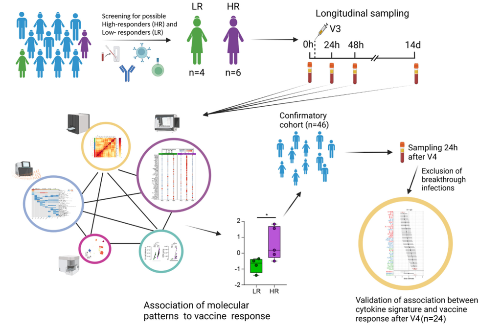

Figure 1: Study design of Odak et al (2024).

**Expected Outcomes**: We anticipate that our analysis will reveal the activation of immune-related genes, particularly those involved in interferon response and antiviral defense. This aligns with findings from the original study.

**Analysis Workflow:** The analysis workflow of this tutorial includes the following steps:

1. **Data Acquisition:** Download gene-level read counts from GEO.
2. **Differential Expression Analysis:** Identify differentially expressed genes (DEGs).
3. **Visualization:** Create volcano plots and heatmaps to visualize expression results.
4. **Cluster Analysis:** Group genes with similar expression profiles across samples.
5. **Interpretation:** Conduct GO and Reactome pathway enrichment analysis to interpret results.

**Note:** This workflow focuses on the downstream analysis and intentionally omits the initial, resource-intensive steps of an RNA-Seq experiment: **(1)** alignment of RNA reads to a reference, and **(2)** counting reads overlapping with annotation features. These upstream steps are not essential for learning purposes, and their exclusion is possible because GEO provides precomputed gene-level read count tables for the chosen dataset.

**Why RNA-seq is a powerful tool in biology?**

RNA-seq enables scientists to simultaneously measure the expression of all genes in a sample. By comparing gene activity across different conditions (e.g., before and after vaccination, healthy vs. diseased tissue, or environmental stress), researchers can identify activated or deactivated biological processes. This bridges the gap between molecular changes and observable outcomes such as immune activation, disease resistance, or developmental shifts, transforming thousands of gene read counts into testable biological insights.

**Learning Outcomes**

Through this activity, students will gain an understanding of how RNA-seq measures gene expression changes and reveals biological responses, specifically in the context of vaccination.

By working with the GSE247401 dataset, students will:

1. Comprehend how RNA-seq data reflects the activity of thousands of genes across samples.
2. Learn how statistical tools like DESeq2 identify significant gene changes between conditions.
3. Gain practical experience with real count data, normalization techniques, and visualization methods (volcano plots and heatmaps).
4. Connect computational results to biological understanding by exploring activated genes and pathways after vaccination.
5. Appreciate the process of converting large raw RNA-seq data files into meaningful insights, such as identifying immune and antiviral responses in blood following vaccination.

## 1.1 Initialize project

To get started with [Posit/RStudio Cloud](https://posit.cloud/), users can follow the instructions below. Instead of Posit Cloud, more advanced users can install everything on their local computer by first installing R from [CRAN](https://cran.r-project.org), and then the free version of Posit/RStudio from [here](https://posit.co/download/rstudio-desktop/). Since the usage of Posit/RStudio Cloud does not require any local software installs, this method is recommended for users who are new to R. For more advanced users the local install option is less restrictive and more flexible. In both cases the user interfaces are extremely similar and the way to run R code is nearly identical.

### 1.1.1 Load project via assignment link

1. Create a free personal account on Posit (RStudio) Cloud [here](https://posit.cloud/).
2. Next click the Posit/RStudio Studio Cloud assignment link provided under the same name on the corresponding assignment page on Canvas [here](https://elearn.ucr.edu/courses/192776/assignments/925649). Note, the latter page is private to this class.
3. Start the pregenerated assignment by clicking the `BIOL119-2025-SA5-HW`. This will create a copy of the assignment in a student’s account.
4. Continue under section 1.2 and skip R package install under section 2.

## 1.2 Load R code and run it

The R code along with the human readable text in this document can be opened and executed as follows:

1. Open source `Rmd` file for this document by selecting in top menu: `File` -> `Open File` -> `exprAnalyisRNAseq.Rmd`. Alternatively, one can click the name of this file in Posit’s (RStudio’s) file browser, usually located in the window on the bottom right. Either option will open the `Rmd` in the code editor window usually located in the top left window.
2. Execute code of the `Rmd` file line by line by placing the cursor on a line of R code and then pressing on the keyboard `Ctrl + Enter`. This will send the corresponding code line to the R console (located on bottom left) and execute (run) the code. It is important to execute the lines in the order given in the `Rmd` file. Note, `Rmd` files are special `R` files that contain both human readable text in markdown format as well as R code located in so called code chunk boxes that are initialized and terminated with a tag line starting with three backtick (`) characters. If an `R` script instead of an `Rmd` script is used then everything works the same. However, in an `R` script human readable text has to be initialized on each line with a comment (`#`) sign.

Alternatively, one can execute all code in this document at once simply by pressing the triangle next to the Knit button above the code editor window in Posti/RStudio, and then selecting `Knit to HTML`. This will not only execute the code, but also regenerate this HTML document and update all output, tables and figures generated by the evaluated R code chunks accordingly. Similarly, one can generate a PDF document instead. The environment that makes this possible is called [R Markdown](https://rmarkdown.rstudio.com/). Importantly, R Markdown files including interactive features, such as interactive tables used in the below *Filter DEGs* section, can only be rendered in a fully functional form to HTML. PDF or MS Word formats do not support interactive features.

# 2 Import Libraries

R packages required for this exercise will be loaded with the `library` command. To suppress verbose messages during the package loading process, the `suppressPackageStartupMessages` is used.

```r
suppressPackageStartupMessages({
  library(SummarizedExperiment)
  library(DESeq2)
  library(edgeR)
  library(gplots)
  library(pheatmap)
  library(ReactomePA)
  library(clusterProfiler)
  library(enrichplot)
  library(org.Hs.eg.db)
  library(ggplot2)
})
```

```r
source("exprAnalysisRNAseq_Fct.R")
```

# 3 Variable Settings

The following sets up the basic information for the RNA-seq analysis. It doesn’t analyze any data yet, it just defines variables that tell R which dataset to download, where to save results, and how to modify sample lables so that they are easy to recognize.

```r
acc          <- "GSE247401" # Defines RNA-Seq data set to download
pre_pat      <- "V3D0$" # Sample tag for pre
post_pat     <- "V3D1$" # Sample tag for post
n_pairs      <- 4 # Number of pairs to choose, not all for simplicty
download_dir <- "data/exprAnalysisRNAseq" # Download directory
out_prefix   <- "GSE247401_V3_pre_vs_post_4pairs" # Prefix to use in file names of results
result_dir   <- "results/exprAnalysisRNAseq/" # Where to write result files
```

# 4 Load counts from GEO

This section loads the RNA-seq count data from GEO and then selects the specific samples to compare: the Pre vs Post vaccination pairs. It also creates a metadata table (`coldata`) describing each sample for later use in the differential gene expression (DEG) analysis with `DESeq2`. Students new to R and RNA-Seq analysis want to pay mainly attention to the resulting `coldata` table that is printed at the end.

```r
cts <- geo_counts_gq(acc, download_dir = download_dir) # Downloads the gene count data
samples <- colnames(cts) # Lists all sample names (column names)
pre   <- grep(pre_pat, samples, value = TRUE) # Pre-vacc. samples with above pattern V3D0
post  <- sub(pre_pat, sub("\\$", "", post_pat), pre, perl = TRUE) # Matches Pre to Post samples
ok    <- post %in% samples # Checks presence of post sample names
pre   <- head(pre[ok],  n_pairs) # Keeps only first pairs (here 4)
post  <- head(post[ok], n_pairs) # Same for post

cts_small <- cts[, c(pre, post), drop = FALSE] # Subsets count matrix to paired samples
coldata   <- data.frame( # Builds a sample information table
  row.names = colnames(cts_small),
  subject   = factor(sub("_(V[23]D[01])$", "", c(pre, post), perl = TRUE)),
  time      = factor(c(rep("pre", length(pre)), rep("post", length(post))), levels = c("pre", "post"))
)
coldata # Displays the resulting metadata table
```

```
##              subject time
## ChAd.01_V3D0 ChAd.01  pre
## ChAd.03_V3D0 ChAd.03  pre
## ChAd.05_V3D0 ChAd.05  pre
## ChAd.07_V3D0 ChAd.07  pre
## ChAd.01_V3D1 ChAd.01 post
## ChAd.03_V3D1 ChAd.03 post
## ChAd.05_V3D1 ChAd.05 post
## ChAd.07_V3D1 ChAd.07 post
```

# 5 DEG Analysis with `DESeq2`

This part runs the differential gene expression analysis using DESeq2, which compares expression levels after vaccination (Post) vs before vaccination (Pre) while accounting for the fact that the same people were sampled twice (paired design).

```r
dds <- DESeqDataSetFromMatrix(cts_small, coldata, design = ~ subject + time)
dds <- dds[rowSums(counts(dds)) >= 10, ]
dds <- DESeq(dds)
res <- results(dds, contrast = c("time", "post", "pre"))
if (requireNamespace("apeglm", quietly = TRUE)) { cf <- resultsNames(dds)[grep("^time_post", resultsNames(dds))][1]; if (!is.na(cf)) res <- lfcShrink(dds, coef = cf, type = "apeglm") }
res_tbl <- as.data.frame(res)
```

The following paragraph gives a short explanation for each code line in the above code chunk. Beginners can ignore this level of detail.

*[Line 1]* Creates a DESeq2 dataset object combining the count data and sample information. The `design = ~ subject + time` formula tells `DESeq2` to control for differences between subjects (subject) and test the main effect of time (pre vs post). Note: this is a simplified design formula for demonstration purposes of this study. *[Line 2]* Removes genes with very low total counts (fewer than 10 reads across all samples). These genes do not provide reliable statistical signals. *[Line 3]* Runs the full DESeq2 workflow: normalization, dispersion estimation, and model fitting for each gene. *[Line 4]* Extracts the comparison results for Post vs Pre vaccination giving log₂ fold changes and adjusted p-values for every gene. *[Line 5]* Optionally applies log fold-change shrinkage using the apeglm method, which reduces noise for genes with low counts and makes fold changes more stable and interpretable. *[Line 6]* Converts the DESeq2 results object into a regular data frame so we can easily filter, plot, and annotate it later.

## 5.1 Annotate DESeq2 results table

This section adds biological meaning to the `res_tbl` table from `DESeq2` by adding additional gene identifiers (gene symbols and Entrez IDs) and their functional descriptions. It connects the statistical results back to biological names and saves them to a tabular file under `./results/exprAnalysisRNAseq/` for reporting, A slice of that table is shown as well, but only the first 100 rows! Next, a normalized expression matrix (`vsd_mat`) is created that will be used for clustering and heatmap visualization in the next steps.

```r
res_annot <- annotate_genes_simple(res_tbl)  # adds gene symbols and functional description
res_annot <- res_annot[order(res_annot$padj),] # Sort by padj column
write.csv(res_annot, # Writes full result table to a file
          paste0(result_dir, out_prefix, "_DESeq2_results_annotated.csv"),
          row.names = FALSE)
DT::datatable(pretty_num(res_annot[1:100, c(10, 8, 1:5)]), options = list(scrollX = TRUE)) # To show full table, remove [1:100, ]
```

|  | entrez_id | gene_clean | baseMean | log2FoldChange | lfcSE | stat | pvalue |
| --- | --- | --- | --- | --- | --- | --- | --- |
| 1 | 5414 | SEPTIN4 | 321.8978 | 2.7947 | 0.3056 | 9.1461 | 5.905e-20 |
| 2 | 23034 | SAMD4A | 250.7127 | 2.5191 | 0.2829 | 8.9045 | 5.364e-19 |
| 3 | 441168 | CALHM6 | 861.9405 | 2.9182 | 0.3348 | 8.7174 | 2.847e-18 |
| 4 | 10410 | IFITM3 | 2.451e+04 | 2.3792 | 0.2740 | 8.6835 | 3.837e-18 |
| 5 | 4938 | OAS1 | 5678.1921 | 2.0316 | 0.2364 | 8.5948 | 8.342e-18 |
| 6 | 467 | ATF3 | 275.6415 | 2.9914 | 0.3587 | 8.3384 | 7.528e-17 |
| 7 | 717 | C2 | 331.0800 | 1.7859 | 0.2141 | 8.3396 | 7.457e-17 |
| 8 | 26509 | MYOF | 913.5943 | 2.1951 | 0.2649 | 8.2856 | 1.175e-16 |
| 9 | 51056 | LAP3 | 4935.1679 | 2.4471 | 0.2968 | 8.2455 | 1.644e-16 |
| 10 | 26010 | SPATS2L | 332.6330 | 1.9064 | 0.2464 | 7.7383 | 1.007e-14 |

[output cut: 90 more lines]

```r
res_tbl$gene <- rownames(res_tbl) # Extracts gene IDs from row name slot
res_tbl <- res_tbl[order(res_tbl$padj), ] # Sorts by adjusted p-value
vsd_mat <- assay(vst(dds, blind = TRUE)) # See below
```

The last line above (with `assays`) creates a variance-stabilized expression matrix for visualization. This transformation (`vst`) removes large differences due to sequencing depth and makes expression values more comparable between samples.

## 5.2 Filter DEGs

This code block filters the `DESeq2` results, identifying significantly changed genes based on robust biological and statistical criteria. Specifically, it isolates genes exhibiting a fold change exceeding 2 (or 1 on log2 scale) and an adjusted p-value below 0.05. This process yields a list of differentially expressed genes (DEGs) that are strongly and significantly altered between Post and Pre-vaccination states. This DEG list will be used for downstream applications such as heatmap plotting and functional interpretation analyses, including GO or Reactome enrichment analysis.

```r
sig_genes <- subset(res_annot, abs(log2FoldChange) > 1 & padj < 0.05)
sig_genes <- sig_genes[order(sig_genes$padj),] # Sort by padj column
DT::datatable(pretty_num(sig_genes[,c(10, 8, 1:5)]), options = list(scrollX = TRUE))
```

|  | entrez_id | gene_clean | baseMean | log2FoldChange | lfcSE | stat | pvalue |
| --- | --- | --- | --- | --- | --- | --- | --- |
| 1 | 5414 | SEPTIN4 | 321.8978 | 2.7947 | 0.3056 | 9.1461 | 5.905e-20 |
| 2 | 23034 | SAMD4A | 250.7127 | 2.5191 | 0.2829 | 8.9045 | 5.364e-19 |
| 3 | 441168 | CALHM6 | 861.9405 | 2.9182 | 0.3348 | 8.7174 | 2.847e-18 |
| 4 | 10410 | IFITM3 | 2.451e+04 | 2.3792 | 0.2740 | 8.6835 | 3.837e-18 |
| 5 | 4938 | OAS1 | 5678.1921 | 2.0316 | 0.2364 | 8.5948 | 8.342e-18 |
| 6 | 467 | ATF3 | 275.6415 | 2.9914 | 0.3587 | 8.3384 | 7.528e-17 |
| 7 | 717 | C2 | 331.0800 | 1.7859 | 0.2141 | 8.3396 | 7.457e-17 |
| 8 | 26509 | MYOF | 913.5943 | 2.1951 | 0.2649 | 8.2856 | 1.175e-16 |
| 9 | 51056 | LAP3 | 4935.1679 | 2.4471 | 0.2968 | 8.2455 | 1.644e-16 |
| 10 | 26010 | SPATS2L | 332.6330 | 1.9064 | 0.2464 | 7.7383 | 1.007e-14 |

[output cut: 261 more lines]

The number of DEGs passing this filter is 271.

# 6 Visualize DEGs: Volcano Plot

A volcano plot is a simple way to visualize which genes change most strongly and significantly after vaccination. In this experiment, each point on the plot represents one gene measured in blood before and 24 hours after the COVID-19 vaccination.

- The x-axis shows the log₂ fold change, how much a gene’s expression increases or decreases after vaccination. Genes on the right side are upregulated (expressed more strongly after vaccination).
- Genes on the left side are downregulated (expressed less strongly after vaccination).
- The y-axis shows the –log₁₀(adjusted p-value) — how statistically significant each change is.
- The higher a point appears, the more confidently that gene is considered to have changed.

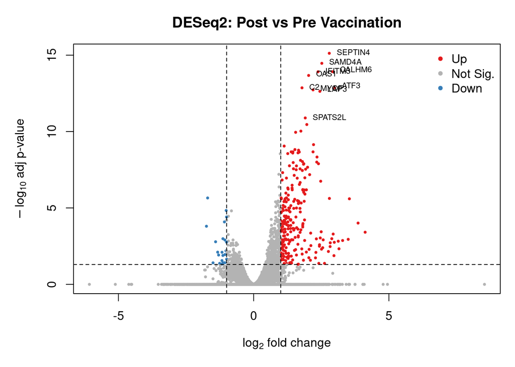

```r
res_for_labels <- res_annot # Usage of gene symbols in plot
res_for_labels$gene <- ifelse(is.na(res_for_labels$symbol), res_for_labels$gene, res_for_labels$symbol)
volcano_simple(res_tbl,
               alpha = 0.05, lfc = 1, label_n = 10,
               device = "screen",
               out = paste0(out_prefix, "_DESeq2"),
               title = "DESeq2: Post vs Pre Vaccination")
```

# 7 Clustering and Heatmap

Note: For visibility the heatmap is plotted only for the top 30 DEGs stored in the `sig_genes` table generated under the *Filter DEGs* section above. To include all 271 from `sig_genes` in the heatmap, remove in the below code the subsetting with `[1:30]`.

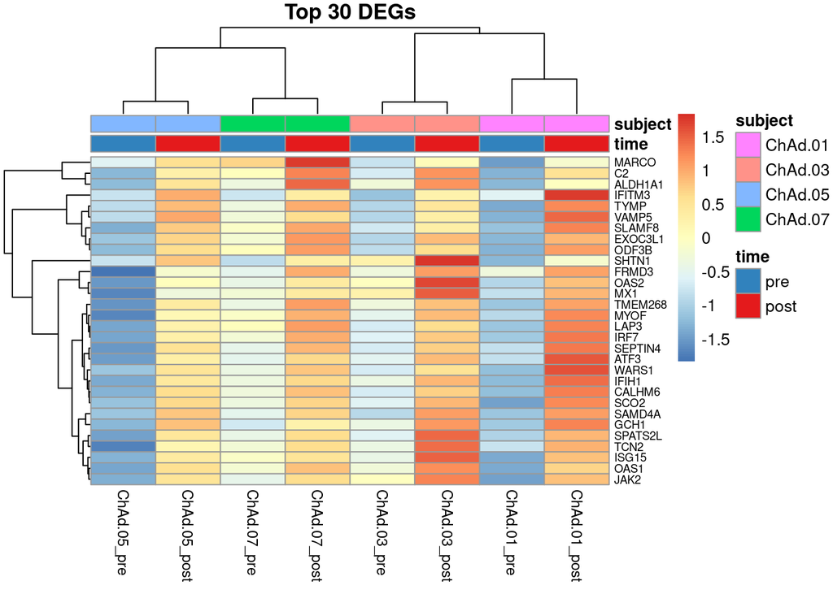

```r
sig_gene_ids <- sig_genes[order(sig_genes$padj), "symbol"] # Extract gene symbols sorted by padj
sig_gene_ids <- sig_gene_ids[1:30] # Subset to top 30 for better visibility in heatmap
mat <- vsd_mat[sig_gene_ids, , drop = FALSE] # Subset rows in vsd_mat to sig_gene_ids
colnames(mat) <- paste(coldata$subject, coldata$time, sep = "_") # Assign column proper column names
annotation_col <- data.frame(time = coldata$time, subject = coldata$subject, row.names = colnames(mat))
ann_colors <- list(time = c(pre = "#3182BD", post = "#E41A1C")) # Optional: custom colors for 'time'
pheatmap(mat,
         scale = "row",
         clustering_distance_rows = "correlation",
         clustering_distance_cols = "correlation",
         clustering_method = "complete",
         annotation_col = annotation_col,
         annotation_colors = ann_colors,
         show_rownames = TRUE,
         show_colnames = TRUE,
         fontsize_row = 7,
         fontsize_col = 9,
         main = paste("Top", length(sig_gene_ids), "DEGs"))
```

# 8 GO Term Enrichment Analysis

This section performs GO Term enrichment analysis with functions provided by the `clusterProfiler` package. Initially, it filters the `DESeq2` results to significant, biologically large changes (`|log₂FC| > 1 and FDR < 0.05`), converts that DEG list to Entrez IDs, and performs Gene Ontology Biological Process (GO BP) enrichment with the `enrichGO` function. The enrichment tests whether DEGs are over-represented in specific biological processes compared with the background of tested genes; for this vaccination dataset. Based on the experimental design, one should expect terms related to innate immunity, interferon signaling, antiviral defense, and cytokine responses. The final barplot displays the top 10 enriched processes by significance, helping to summarize which biological programs are most activated post-vaccination.

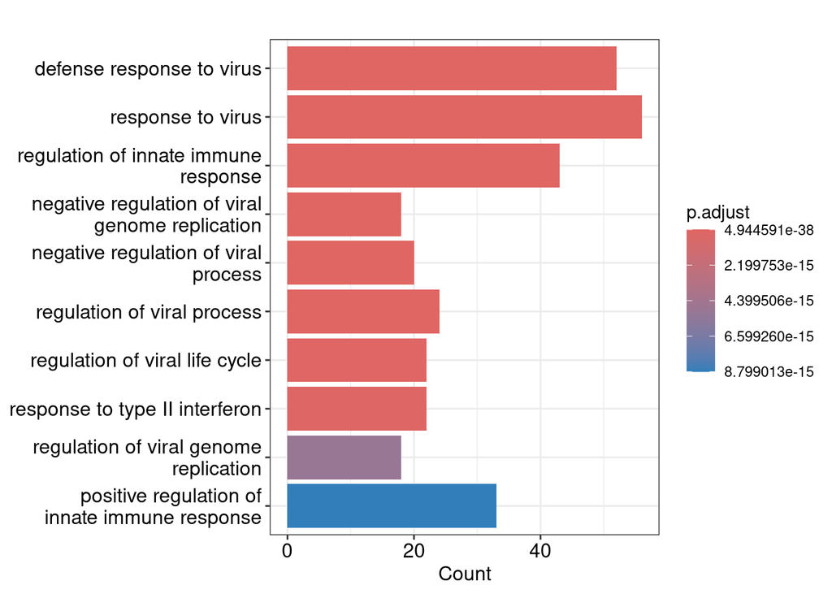

```r
degs <- subset(res_annot, abs(log2FoldChange) > 1 & padj < 0.05)
degs <- na.omit(sig_genes$entrez_id)
ego_bp <- enrichGO(gene = degs, OrgDb = org.Hs.eg.db, keyType = "ENTREZID", ont = "BP")
barplot(ego_bp, showCategory=10)
```

# 9 Pathway Enrichment Analysis

This code performs a Reactome pathway enrichment analysis, which helps identify biological pathways that are significantly affected by the genes changing after vaccination.

First, it selects the significant genes (`sig_de`) that meet both a fold change cutoff (|log₂FC| ≥ 1) and an adjusted p-value < 0.05, then extracts their Entrez IDs (`entrez_sel`), which are the standardized identifiers required by most enrichment tools. Next, it defines a background universe (`bg_universe`), the set of all genes that were tested in the experiment to ensure that enrichment results are statistically well-calibrated. The `enrichPathway` function (from the ReactomePA package) then checks whether the significant genes are overrepresented in specific Reactome pathways compared with this background. These pathways correspond to curated molecular systems such as Interferon Signaling, Cytokine Signaling, or Antiviral Mechanisms. Finally, `setReadable` converts the Entrez IDs back to human-readable gene symbols, making the enrichment results easier to interpret.

In summary, this code identifies which biological pathways are most strongly activated or repressed after COVID-19 vaccination, revealing the coordinated immune responses behind the differential gene expression results.

```r
degs <- subset(res_annot, abs(log2FoldChange) >= 1 & padj < 0.05)
entrez_sel <- unique(na.omit(degs$entrez_id))
bg_universe <- unique(na.omit(res_annot$entrez_id))
er <- enrichPathway(gene = entrez_sel, organism = "human", pAdjustMethod = "BH", pvalueCutoff= 0.05, qvalueCutoff  = 0.05, universe = bg_universe, readable = FALSE)
er_readable <- setReadable(er, OrgDb = org.Hs.eg.db, keyType = "ENTREZID")
```

Next, the enrichment resuls are plotted as dot and bar plots. Here is a short description for interpreting these plots and what they mean for this vaccination study:

Dot plot (`dotplot`): Each row is a Reactome pathway; the x-axis shows the GeneRatio (fraction of significant genes that fall in that pathway), the dot size shows the Count (how many DE genes hit the pathway), and the dot color encodes adjusted p-value (often a gradient where darker/warmer = more significant after multiple-testing correction). Pathways toward the right with large, dark dots are enriched in DEGs, such as Interferon Signaling.

Bar plot (`barplot`): Shows the top pathways ranked by enrichment; the bar length is typically the Count (number of DE genes in each pathway), and bars may be colored by adjusted p-value. Long bars near the top indicate pathways with the highest enrichment. Seeing multiple, related immune pathways (e.g., interferon, antigen presentation) near the top confirms a coordinated early innate response consistent with the study design (Post vs Pre within the same people).

Interpretation tips: Focus on pathways that are (1) highly significant (strong color), (2) involve many DE genes (big dots/long bars), and (3) make biological sense together (immune/antiviral clusters). Remember that pathways overlap, thus one should use them as themes rather than isolated entities.

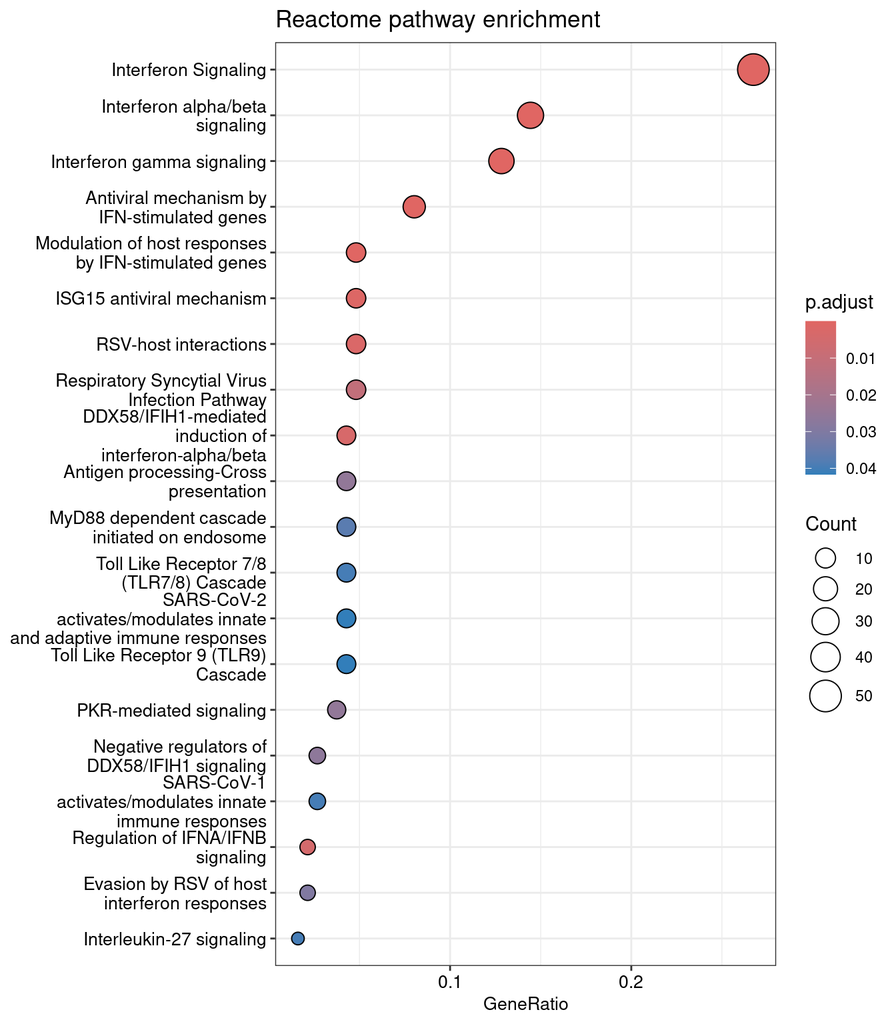

```r
dotplot(er_readable, showCategory = 20, font.size = 10) + ggtitle("Reactome pathway enrichment")
```

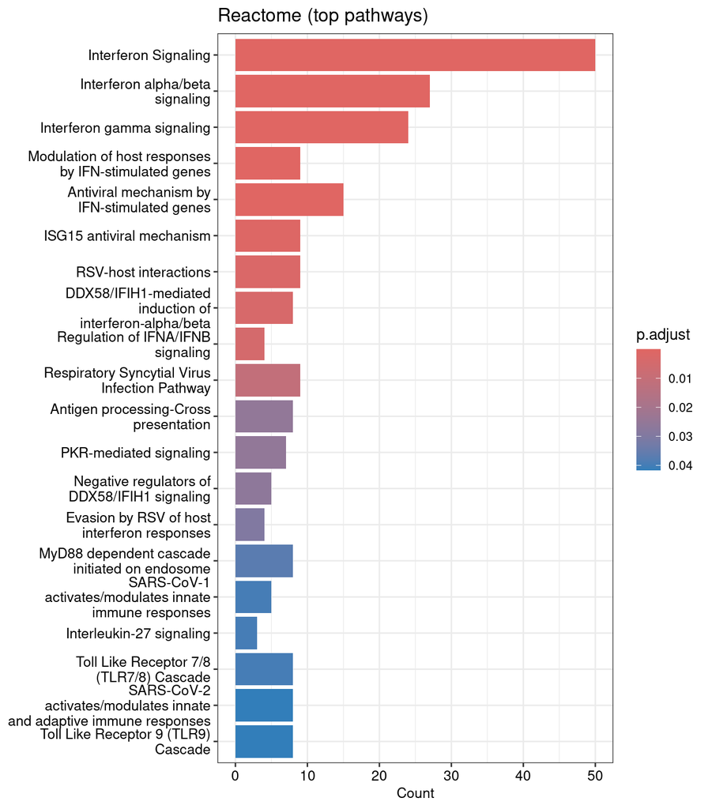

```r
barplot(er_readable, showCategory = 20, font.size = 10) + ggtitle("Reactome (top pathways)")
```

# 10 Browse Pathways in Reactome

The following command can be used to visually explore the biology behind the statistical results of this analysis workflow, linking the identified DEG list to a real molecular network inside the [Reactome](https://reactome.org/) database.

In detail, the command automatically opens the Reactome Pathway Browser in as user’s web browser for one of the top enriched pathways identified in the analysis. The object `top_path` stores the Reactome pathway ID (for example, R-HSA-913531 for Interferon Signaling). When running this command, it builds the full URL to that pathway and tells R to open it, similar to clicking a link. Clicking this [R-HSA-913531 pathway](https://reactome.org/PathwayBrowser/#/R-HSA-913531) link will open the same Reactome pathway for testing without running the code.

Once the page opens, one can see an interactive diagram showing how different molecules and genes interact in that pathway. Each node or reaction represents a protein, gene product, or biological event, and one can hover or click to read detailed descriptions. If this pathway came up as significantly enriched in the results, it means that many of the genes activated after vaccination participate in that biological process. When exploring these pathways, one should look for:

- where significant genes appear,
- whether most are up-regulated (immune activation) or down-regulated and
- how these changes fit the experiment’s goal—here, understanding how vaccination triggers the body’s early antiviral response.

```r
top_path <- er_readable@result$ID[1]
browseURL(paste0("https://reactome.org/PathwayBrowser/#/", top_path))
```

Reactome’s pathways are highly useful for biology and biomedical research because they provide a curated, organized view of biological processes and molecular interactions, offering a clear framework for learning complex cellular mechanisms. In the context of large-scale data, Reactome helps students interpret experimental results by linking differentially expressed genes or proteins to specific, well-defined biological pathways, enabling functional analysis and interpretation of the ‘omics’ data.

The following shows all human pathways in Reactome as a fireworks plot. This is a static image not created by the above code directly.

[figure not shown]

# References

Odak, Ivan, Lennart Riemann, Inga Sandrock, Anne Cossmann, Gema Morillas Ramos, Swantje I Hammerschmidt, Christiane Ritter, et al. 2024. “Systems biology analysis reveals distinct molecular signatures associated with immune responsiveness to the BNT162b COVID-19 vaccine.” *EBioMedicine* 99 (104947): 104947. https://doi.org/10.1016/j.ebiom.2023.104947.